# Experiment: effect of Universal Basic Income implementation

by JUMEX365

### Installing packages

```r
library(reldist)
library(IC2)
library(ggplot2)
library(dplyr)
```

```r
options(scipen = 999)
```

### Changing data to unique one

Here I changed seed to 777 (which helps to create pseudo random numbers) and made 2000 observations per city.

```r
set.seed(777)
city <- c("A", "B", "C", "D", "E", "F", "G", "H")
income <- sample(1:100000,
                 16000,
                 replace = TRUE)
cities_pr5 <- data.frame(city, income) %>% arrange(city)
```

### UBI implementation: adding coloumns and vectors with calculations

```r
cities_pr5 = cities_pr5 %>% mutate("income-taxes" = 0.6*income)
cities_pr5 = cities_pr5 %>% mutate("taxes" = 0.4*income)
sum_tax = sum(cities_pr5$taxes)
UBI = sum_tax / 16000
cities_pr5 = cities_pr5 %>% mutate("income+UBI" = income-taxes + UBI)
```

UBI in my case will be the following:

```r
UBI
```

```
## [1] 20026.54
```

### “Lorenz - Gini graphs cities”

**Default income**

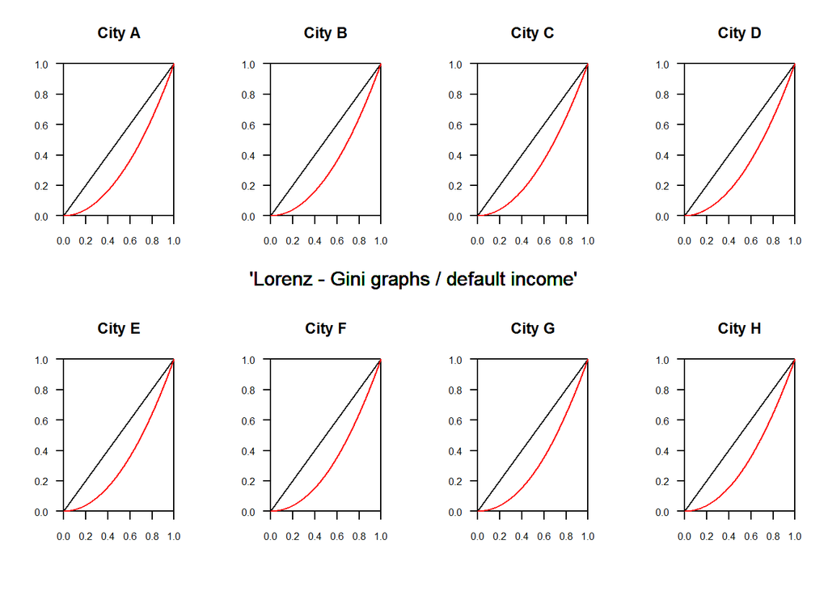

```r
par(mfrow=c(2,4))
for (i in LETTERS[1:8]) {
  cities_pr5 %>% filter(city == i) %>% .$income %>% curveLorenz(., col = 'red')
  title(paste('City', i))
  mtext("'Lorenz - Gini graphs / default income'", side = 3, line = -18.5, outer = TRUE)
}
```

From the graphs we can see that income inequality in all cities is significant. It is hard to choose some with the highest inequality but I think it is F and H.

**Income with UBI**

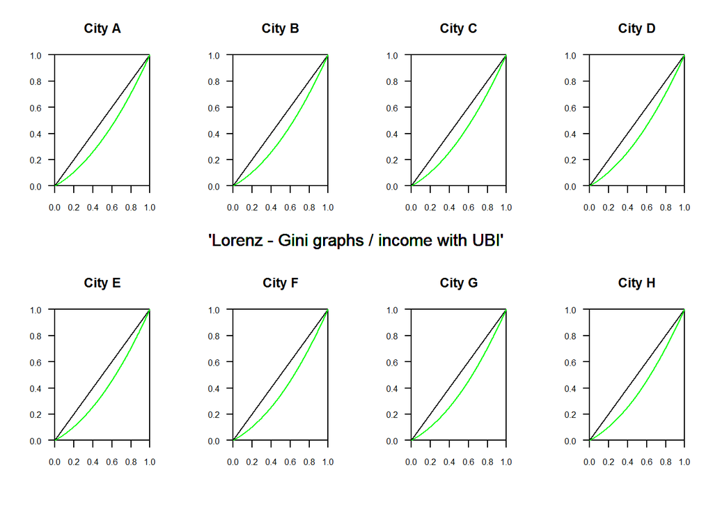

```r
par(mfrow=c(2,4))
for (i in LETTERS[1:8]) {
  cities_pr5 %>% filter(city == i) %>% .$"income+UBI" %>% curveLorenz(., col = 'green')
  title(paste('City', i))
  mtext("'Lorenz - Gini graphs / income with UBI'", side = 3, line = -18.5, outer = TRUE)
}
```

Compared with case with default income, here in income + UBI, we can observe decrease in inequality for all cities. But now I cannot choose cities with highest inequality, because they seems to me so similar. It is good idea to look at Gini coefficients.

### Calculating and comparing Gini coefficients.

**Default income**

```r
Gini_calculations_def <- aggregate(income ~ city,
                        data = cities_pr5,
                        FUN = "gini")
names(Gini_calculations_def) <- c("city", "gini")
knitr::kable(Gini_calculations_def %>% arrange(desc(gini)), align = 'l')
```

| city | gini |
| --- | --- |
| F | 0.3410869 |
| G | 0.3406048 |
| H | 0.3363977 |
| E | 0.3350047 |
| B | 0.3318137 |
| A | 0.3286765 |
| D | 0.3273221 |
| C | 0.3249439 |

Here is Gini coefficients before introduction of UBI, and my expectations filled partly. Indeed the city with highest inequality is F, than it goes G, and then H(My second prediction).

**Income with UBI**

```r
Gini_calculations_ubi <- aggregate(income+UBI ~ city,
                        data = cities_pr5,
                        FUN = "gini")
names(Gini_calculations_ubi) <- c("city", "gini")
knitr::kable(Gini_calculations_ubi %>% arrange(desc(gini)), align = 'l')
```

| city | gini |
| --- | --- |
| F | 0.2433696 |
| G | 0.2428671 |
| H | 0.2405151 |
| E | 0.2390130 |
| B | 0.2368015 |
| A | 0.2340736 |
| D | 0.2340577 |
| C | 0.2334099 |

Here is Gini coefficients after introduction of UBI. And again we can see, that for all cities inequality decreased (at least for ~ 0.1). But the cities with the highest inequality remained the same: F, G, H.

### “Lorenz - Gini graphs country”

**Default income**

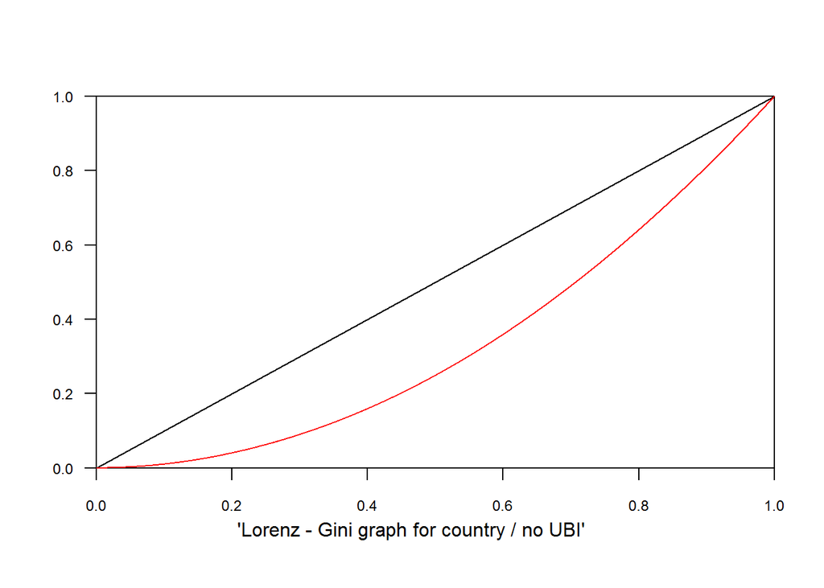

```r
curveLorenz(cities_pr5$income, col = 'red')
mtext("'Lorenz - Gini graph for country / no UBI'", side = 3, line = -23, outer = TRUE)
```

Well, for default income nationwide it is obvious that income inequality is significant.

**Income with UBI**

[figure not shown]

```r
curveLorenz(cities_pr5$income+UBI, col = 'green')
mtext("'Lorenz - Gini graph for country / with taxes and UBI'", side = 3, line = -23, outer = TRUE)
```

After introduction of UBI nationwide, it is obvious, that income inequality decreased somehow (but it is still not zero)

**Default income** Gini coeficient:

```r
gini(cities_pr5$income)
```

```
## [1] 0.3333241
```

**Income with UBI** Gini coeficient:

```r
gini(cities_pr5$income+UBI)
```

```
## [1] 0.2380887
```

Now we can analyze Gini coefficients nationwide. According to them, inequality has indeed decreased. The difference in Gini is the following:

```r
Difference = gini(cities_pr5$income) - gini(cities_pr5$income+UBI)
Difference
```

```
## [1] 0.09523546
```

Seems not bad XD

### Final words

Our theoretical experiment showed that the redistribution of income through the introduction of a fairly large tax and its subsequent transformation in UBI is a good tool for reducing income inequality.